# EDA and Visualization

### EDA and Visualization

EDA (Exploratory Data Analysis) is the next step in the work of the data scientist. We will conduct an in-depth analysis of the data, and through visualizations, we can begin to answer questions and draw conclusions.

```python
import pandas as pd
import numpy as np
import matplotlib as mpl
from matplotlib import pyplot as plt
import seaborn as sns
from scipy.stats import chi2_contingency
from mpl_toolkits.mplot3d import Axes3D
%matplotlib inline
```

We will start by adding a decade column derived from the year column. This column will be useful in data analysis.

```python
df = pd.read_csv('full_after_processing.csv')
df = df[['artist', 'song', 'genres', 'year', 'key', 'mode', 'duration', 'bpm']]  # Dropping the 'Unnamed: 0' column
decades = [((s//10)*10) for s in df['year'].copy()]
df['decade'] = pd.Series(decades)
df.head()
```

|  | artist | song | genres | year | key | mode | duration | bpm | decade |
| --- | --- | --- | --- | --- | --- | --- | --- | --- | --- |
| 0 | Kendrick Lamar | Alright | Hip Hop | 2015 | G | 1 | 219 | 110 | 2010 |
| 1 | Beyoncé | Formation | Hip Hop | 2016 | C♯/D♭ | 1 | 206 | 61 | 2010 |
| 2 | Grimes | Oblivion | Pop | 2012 | D | 1 | 251 | 156 | 2010 |
| 3 | Lorde | Royals | Pop | 2013 | G | 1 | 190 | 85 | 2010 |
| 4 | Lana Del Rey | Video Games | Pop | 2011 | F♯/G♭ | 0 | 282 | 122 | 2010 |

#### Single variable visualization

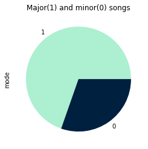

```python
colors = ['#ADEFD1FF', '#00203FFF', '#B8D991FF', '#F8E6A6FF']
df['mode'].value_counts().plot(kind='pie', colors=colors)
plt.title('Major(1) and minor(0) songs')
```

As we can see, the majority of the songs are on a major scale.

We will examine the distribution of songs in the data by decades.

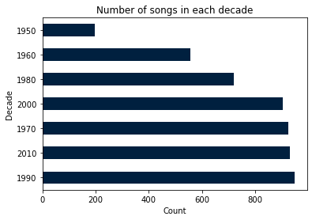

```python
df['decade'].value_counts().plot(kind='barh', color=colors[1])
plt.xlabel('Count')
plt.ylabel('Decade')
plt.title('Number of songs in each decade')
```

Most of the songs are between the years 1980-2019, Let's look in a higher resolution.

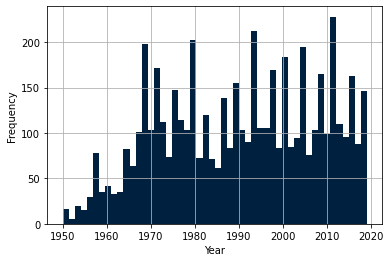

```python
df['year'].hist(bins=50, color=colors[1])
plt.xlabel('Year')
plt.ylabel('Frequency')
```

Same results.

The next thing we will look at is the bpm distribution of the song.

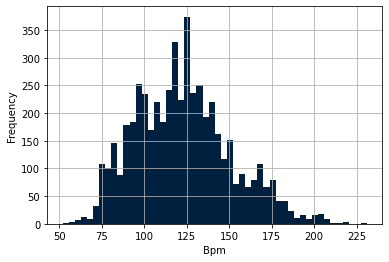

```python
df['bpm'].hist(bins=50, color=colors[1])
plt.xlabel('Bpm')
plt.ylabel('Frequency')
```

Most of the songs are at bpm of 75-150. We notice a jump in the number of songs at 120 bpm. Why? After researching online, it seems that there are 2 theories.

1. 120 is exactly 2 beats per second, so the human ear is used to this rhythm.
2. Most of the popular digital music production software comes at a default bpm of 120.

In order to check the second theory, we will can look at the number of 120bpm songs over the years.

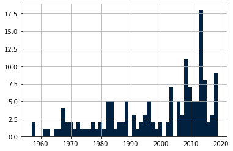

```python
(df[df['bpm'] == 120])['year'].hist(bins=50, color=colors[1])
```

It seems that there has been an increase in songs at the rate of 120 in the mid-2000s. This increase reinforces the theory that the reason behind songs at this pace is the digital production software that gained momentum during this period.

#### Cross Tabulation

We will use Cross Tabulation to test the relationship between two categorical variables. We will start by looking at the division into musical genres by decade.

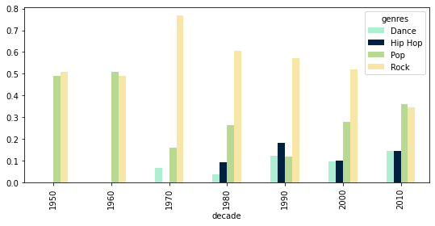

```python
ct1 = pd.crosstab(df['decade'], df['genres'], normalize='index')
ct1.plot(kind='bar', figsize=(9,4), color=colors)
```

The next thing we will check out is the mode of the song (major/minor) and the music genre.

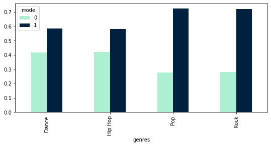

```python
ct2 = pd.crosstab(df['genres'], df['mode'], normalize='index')
ct2.plot(kind='bar', figsize=(9,4), color=colors)
```

We can see that in all genres major songs are leading. In Dance and Hip Hop, the modes are more balanced.

We will use violin plot too look at the duration of the songs distribution among the decades.

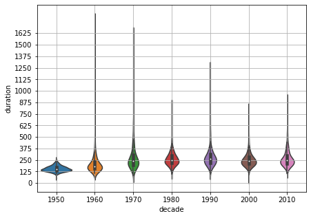

```python
fig = plt.figure(figsize=(7, 5))
sns.violinplot(x=df['decade'], y=df['duration'], normalize='index', grid=True)
plt.yticks(np.arange(0, 1750, 125))
plt.grid()
```

Let's use a line plot to see the same connection. But now, we will also add a plot to the bpm feature.

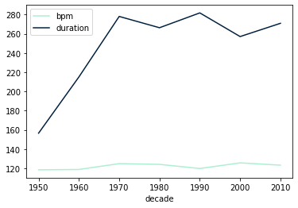

```python
graph = df.groupby(['decade']).mean()[['bpm', 'duration']]
graph.plot(color=colors)
```

there is no drastic change in the mean bpm feature among the years.

#### Scatter Plot

We will use a scatter plot to map the songs using the bpm-suration axis system. We will color each genre a different color.

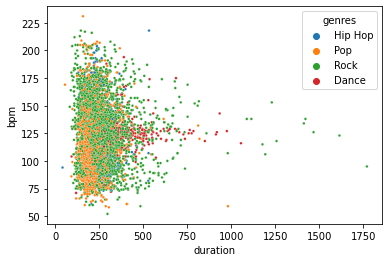

```python
sns.scatterplot(x = 'duration', y = 'bpm', s = 7, hue = 'genres', data=df)
```

#### 3D Scatter Plot

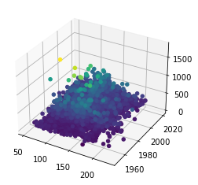

```python
ax = plt.axes(projection='3d')
ax.scatter3D(df.bpm, df.year, df.duration, c=df.duration, depthshade=False)
```

#### Pair plots

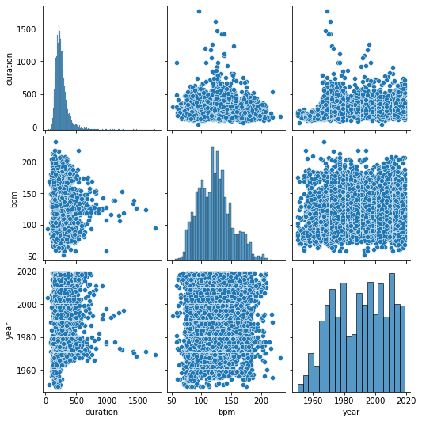

```python
sns.pairplot(df[['duration', 'bpm', 'year']])
```

#### Heat Map

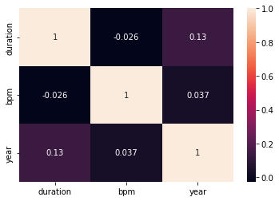

```python
df2 = pd.DataFrame(df, columns = ['duration', 'bpm', 'year'])
sns.heatmap(df2.corr(), annot=True)
```

The last four graphs were exploratory, unfortunately they did not provide us with additional information about the data.